# Numpy and MatPlotLib

## Modifying line and point appearance.

The matplotlib package makes it fairly easy to alter the appearance of lines and points.

First, let's make a basic figure with some simulated data and a candidate function for the data.

```python
# make some simulated data
dat_x = [0, 1, 2, 3, 4, 5, 6]
dat_y = np.sin(dat_x) + 0.25*np.random.randn(len(dat_x))

# make the fitting function
x = np.linspace(0, 2*np.pi, 100)
# compute the sine
y = np.sin(x)
```

Now let's plot these, letting matplotlib pick the default appearance.

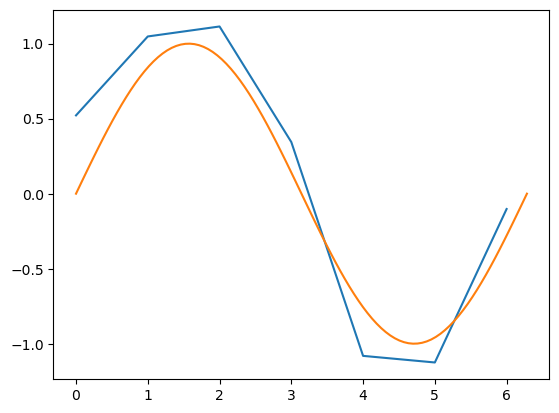

```python
plt.plot(dat_x, dat_y)
plt.plot(x, y)
```

There are some key elements that this figure are missing, as covered above, so use the code cell below to make a figure with those added.

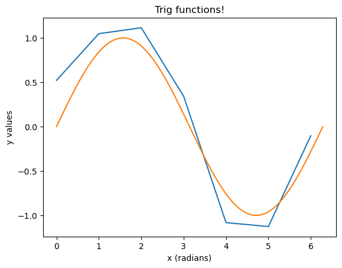

```python
plt.plot(dat_x, dat_y)
plt.plot(x, y)

# annotate
plt.xlabel('x (radians)')
plt.ylabel('y values')
plt.title('Trig functions!')
```

So far so good, but we can do better. The data are sparse – they're only 7 points or so – and they are a bit noisy. So let's let them be points, and make them blue.

Just run the code and we can worry about labels and such in a bit.

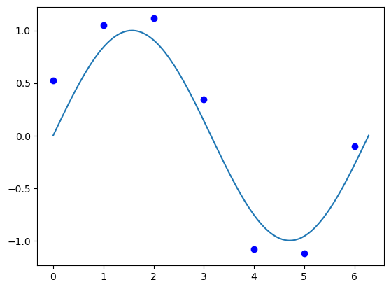

```python
plt.plot(dat_x, dat_y, 'bo')
plt.plot(x, y)
```

This is much better. We have individual data points that almost say out loud "Here's a small sample of data" and a continuous line that says "Here's a smooth function that might describe the data pretty well."

The `'ob'` inside `plt.plot()` is a ***format string*** for plots. This one says "I want my data plotted as blue (the 'b') circles (the 'o').

The general format for these format strings is `[color][marker][line]` but any can be omitted. Here are some common ones:

- colors: `b`, `g`, `r`, `c`, `m`, `y`, `k`
- markers: `.` , `o`, `+`, `x`, `*`, `D`
- lines: `-` , `--` , `-.` , `:`

Here's a secret: you can generally put the elements of the format string in any order you want. One less thing to remember!

You can also play around with things like the size of the markers, width of the lines, and transparency ("alpha" in computer graphics lingo).

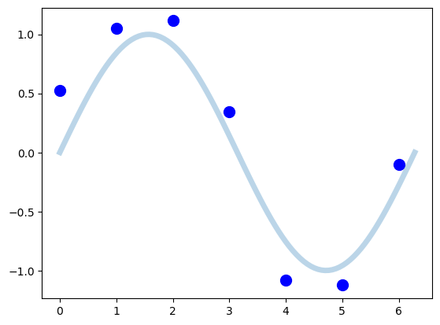

```python
plt.plot(dat_x, dat_y, 'bo', markersize = 10)
plt.plot(x, y, linewidth = 5, alpha = 0.3)
```

You can find more information on what markers, lines, and colors are available and other tips and tricks [here](https://matplotlib.org/stable/api/_as_gen/matplotlib.pyplot.plot.html).

Use the code cells below to make three plots with different markers, lines, etc. Make sure to add axis labels and legends.

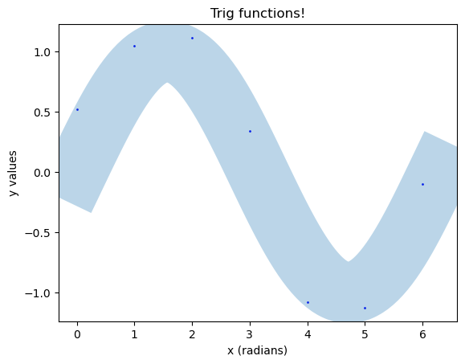

```python
plt.plot(dat_x, dat_y, 'bo', markersize = 1)
plt.plot(x, y, linewidth = 55, alpha = 0.3)

# annotate
plt.xlabel('x (radians)')
plt.ylabel('y values')
plt.title('Trig functions!')
```

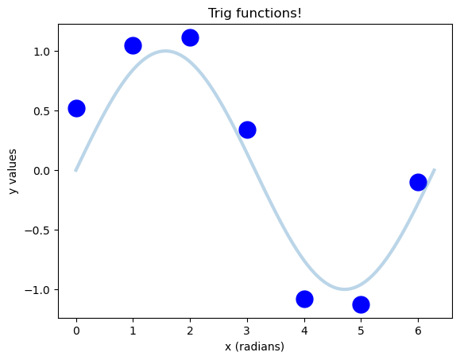

```python
plt.plot(dat_x, dat_y, 'bo', markersize = 15)
plt.plot(x, y, linewidth = 3, alpha = 0.3)

# annotate
plt.xlabel('x (radians)')
plt.ylabel('y values')
plt.title('Trig functions!')
```

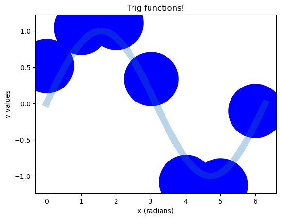

```python
plt.plot(dat_x, dat_y, 'bo', markersize = 80)
plt.plot(x, y, linewidth = 10, alpha = 0.3)

# annotate
plt.xlabel('x (radians)')
plt.ylabel('y values')
plt.title('Trig functions!')
```

## Some basic plot types

Some basic plot types in matplotlib are

- *histograms* – the distributions of a single variable
- *line plots* – two variables with the x axis in numerical order
- *scatterplots* – two variables with potentially more mapped to color and or size

### histograms

Here's an example of plotting a histogram.

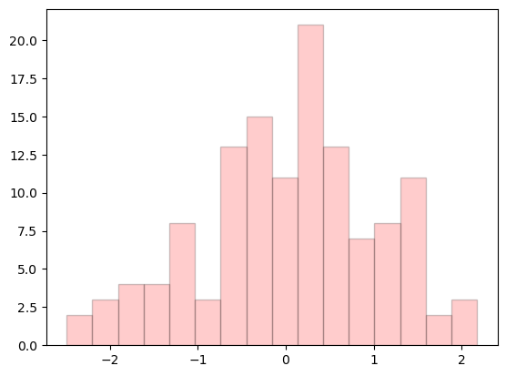

```python
data = np.random.randn(128)
plt.hist(data, bins = 16, color = 'r', edgecolor = 'k', alpha = 0.2);
```

Sometimes, a plot command outputs some annoying text on top of our plot. We can suppress it with a semicolon at the end of the command. Go back up to the above cell and re-run it with the semicolon after the `plt.hist()` command.

Ah! So much better!

Play around with the `bins` parameter for the above plot. Use the cells below to make histograms that you think have 1) to few bins, 2) to many bins and, 3) a Goldilocks number of bins.

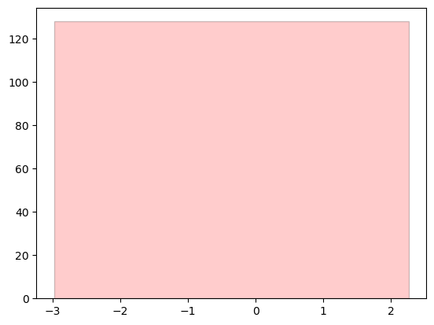

```python
data = np.random.randn(128)
plt.hist(data, bins = 1, color = 'r', edgecolor = 'k', alpha = 0.2);
```

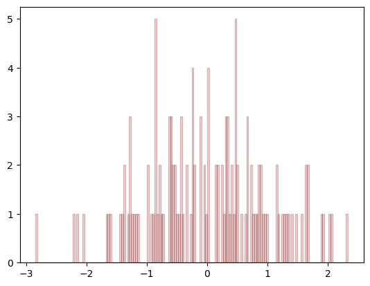

```python
data = np.random.randn(128)
plt.hist(data, bins = 160, color = 'r', edgecolor = 'k', alpha = 0.2);
```

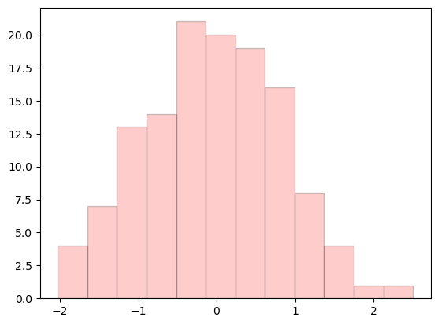

```python
data = np.random.randn(128)
plt.hist(data, bins = 12, color = 'r', edgecolor = 'k', alpha = 0.2);
```

### "plots" (line plots)

We've already played with line plots a bit – these are generated by `plt.plot()`.

The plot below (after you run the code cell) is technically a "line plot". It's so named because the data points *could* be connected with an interpolating line, even if they're not at the moment.

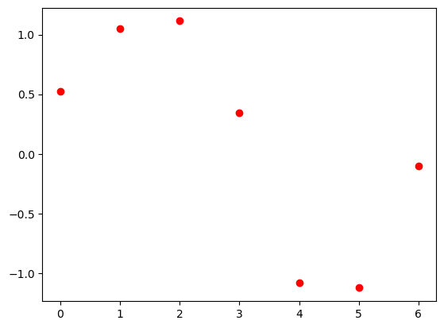

```python
plt.plot(dat_x, dat_y, 'ro')
```

Like this.

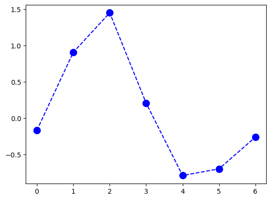

```python
dat_x = [0, 1, 2, 3, 4, 5, 6] # same as above
dat_y = np.sin(dat_x) + 0.25*np.random.randn(len(dat_x))

plt.plot(dat_x, dat_y, 'bo--', markersize = 10);
```

But now let's see what happens when the x values are not ordered.

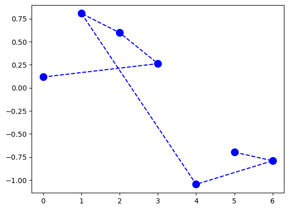

```python
dat_x = [0, 3, 2, 1, 4, 6, 5]
dat_y = np.sin(dat_x) + 0.25*np.random.randn(len(dat_x))

plt.plot(dat_x, dat_y, 'bo--', markersize = 10);
```

Hm. Yeah, not good. Let's re-plot with the code below.

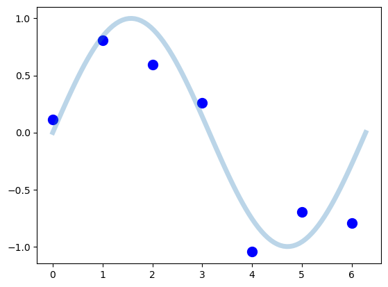

```python
plt.plot(dat_x, dat_y, 'bo', markersize = 10);
plt.plot(x, y, linewidth = 5, alpha = 0.3)
```

We can see that a sine is still a pretty good description of the data, but the line connecting the data points in the plot before this one was very misleading because it connected the dots in the order that the data were listed.

### scatterplots

Scatter plots are like line plots in that they plot one variable on the y axis against another variable on the x axis. They don't offer an option to connect the points with a line. But, unlike line plots, *scatterplots allow you to map other variables onto the size or color of the points*.

Here's a scatterplot of totally random data showing how variables can be used to change color and size. Inside the `plt.scatter()` function, the `s` and `c` parameters are used to set the sizes and colors of the data points.

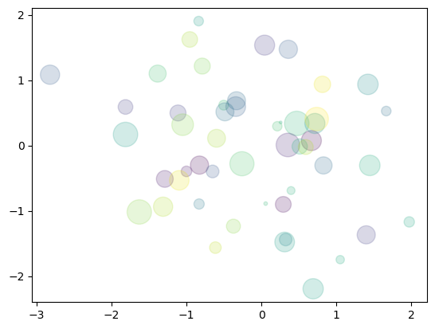

```python
my_x = np.random.randn(50) # normally distributed x
my_y = np.random.randn(50) # and y
my_sizes = 500 * np.random.rand(50) # random sizes
my_colors = np.random.rand(50) #  colormap numbers 0 to 1

plt.scatter(my_x, my_y, s = my_sizes, c = my_colors, alpha = 0.2)
```

You can use different colormaps to map the data to various colors using the `cmap` parameter.

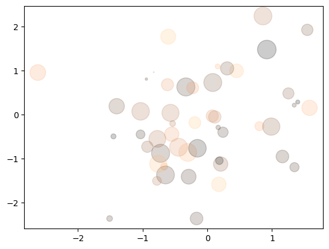

```python
my_x = np.random.randn(50) # normally distributed x
my_y = np.random.randn(50) # and y
my_sizes = 500 * np.random.rand(50) # random sizes
my_colors = np.random.rand(50) #  colormap numbers 0 to 1

plt.scatter(my_x, my_y, s = my_sizes, c = my_colors, alpha = 0.2, cmap = 'copper')
```

You can check out the different built-in colormaps [here](https://matplotlib.org/stable/tutorials/colors/colormaps.html).

Play around with some different colormaps and show us a scatterplot using your favorite.

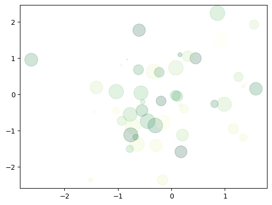

```python
plt.scatter(my_x, my_y, s = my_sizes, c = my_colors, alpha = 0.2, cmap = 'YlGn')
```

As another little example, here are some toy data on the leg length of 9 dogs, the body length of the same dogs, and a third variable coding the breed.

```python
leg_len = np.array([15, 13, 17, 20, 25, 28, 14, 12, 16])
body_len = np.array([29, 27, 32, 35, 41, 44, 40, 33, 45])
breed = np.array([0, 0, 0, 1, 1, 1, 2, 2, 2])
```

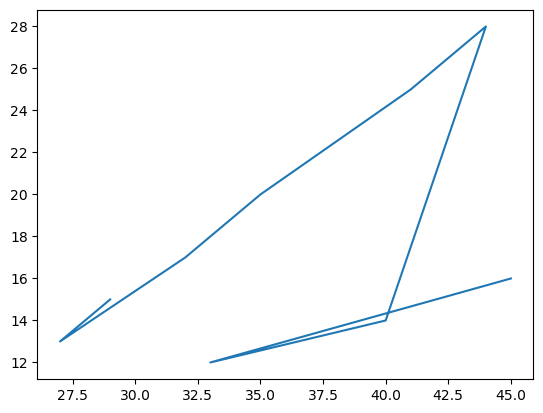

```python
plt.plot(body_len, leg_len)
```

Hm, well, that's not very useful.

Let's give it another go with a scatter plot, mapping the breed variable to data point color.

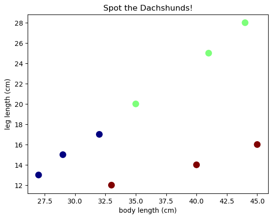

```python
plt.scatter(body_len, leg_len, c = breed/2, s = 80, cmap = 'jet')
plt.xlabel('body length (cm)')
plt.ylabel('leg length (cm)')
plt.title('Spot the Dachshunds!')
```

Okay, now it seems pretty clear that two of the breeds fall on a single trend line relating leg length to body length, whereas another breed is on a different line altogether.

We can make this more clear by adding a diagonal reference line to the plot.

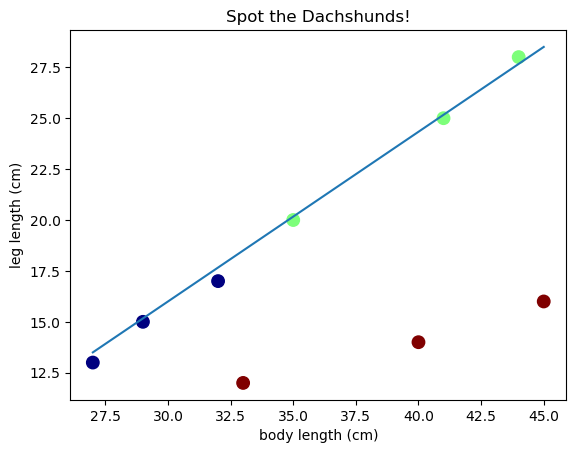

```python
plt.scatter(body_len, leg_len, c = breed/2, s = 80, cmap = 'jet')

# add a reference line
x_ref_line = np.linspace(27, 45) # x value endpoints
y_ref_line = x_ref_line/1.2 - 9  # y calculated using "by-hand" slope and y-int estimates
plt.plot(x_ref_line, y_ref_line)
plt.xlabel('body length (cm)')
plt.ylabel('leg length (cm)')
plt.title('Spot the Dachshunds!')
```

In the cell below, see if you can add a second reference line to the doggy plot to capture the Dachshund data.

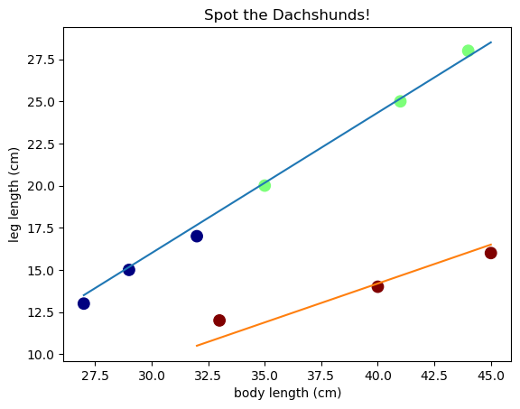

```python
plt.scatter(body_len, leg_len, c = breed/2, s = 80, cmap = 'jet')

# add a reference line
x_ref_line = np.linspace(27, 45) # x value endpoints
y_ref_line = x_ref_line/1.2 - 9  # y calculated using "by-hand" slope and y-int estimates

x_ref_line2 = np.linspace(32, 45) # x value endpoints
y_ref_line2 = x_ref_line/3 + 1.5
plt.plot(x_ref_line, y_ref_line)
plt.plot(x_ref_line2, y_ref_line2)
plt.xlabel('body length (cm)')
plt.ylabel('leg length (cm)')
plt.title('Spot the Dachshunds!')
```